# Discussion - Week11

David Simbandumwe

```r
library(matlib)
library(pracma)
library(readr)
library(dplyr)
```

# Hotels Las Vegas Strip

Abstract: This dataset includes quantitative and categorical features from online reviews from 21 hotels located in Las Vegas Strip, extracted from TripAdvisor ([Web Link]).

Data Set Information: All the 504 reviews were collected between January and August of 2015.

Attribute Information: The dataset contains 504 records and 20 tuned features (as of “status = included”, from Table 1 of the article mentioned below), 24 per hotel (two per each month, randomly selected), regarding the year of 2015. The CSV contains a header, with the names of the columns corresponding to the features marked as “status = included”, from Table 1 of the aforementioned article.

- H0 - Hotel star rating does not predict the review score for a hotel in Las Vegas
- H1 - Hotel star rating predicts the review score for a hotel in Las Vegas

```r
destfile <- tempfile()
download.file("https://archive.ics.uci.edu/ml/machine-learning-databases/00397/LasVegasTripAdvisorReviews-Dataset.csv", destfile)
df <- read_delim(destfile, delim=';' ,col_names = TRUE, col_types = list('Hotel stars' = col_integer()))
mylm <- lm(df$Score ~ df$'Hotel stars')
summary(mylm)
```

```
##
## Call:
## lm(formula = df$Score ~ df$"Hotel stars")
##
## Residuals:
##     Min      1Q  Median      3Q     Max
## -3.3369 -0.3369  0.3262  0.6631  1.3262
##
## Coefficients:
##                  Estimate Std. Error t value Pr(>|t|)
## (Intercept)       2.67908    0.26070  10.277  < 2e-16 ***
## df$"Hotel stars"  0.33156    0.06047   5.483 7.35e-08 ***
## ---
## Signif. codes:  0 '***' 0.001 '**' 0.01 '*' 0.05 '.' 0.1 ' ' 1
##
## Residual standard error: 0.9851 on 406 degrees of freedom
##   (96 observations deleted due to missingness)
## Multiple R-squared:  0.06895,    Adjusted R-squared:  0.06666
## F-statistic: 30.07 on 1 and 406 DF,  p-value: 7.351e-08
```

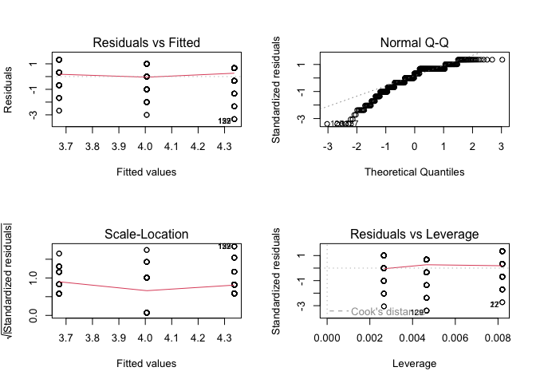

```r
par(mfrow=c(2,2))
plot(mylm)
```

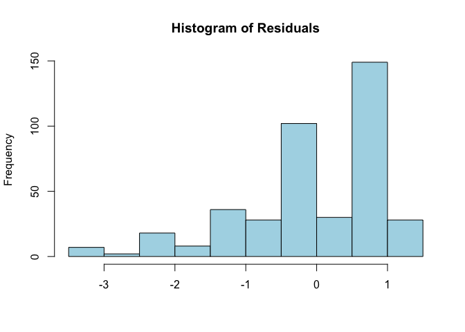

```r
hist(mylm$residuals, main = "Histogram of Residuals", xlab= "", col= "lightblue")
```